# NLP_Project_FullCode

## **Problem Statement**

### Business Context

The prices of the stocks of companies listed under a global exchange are influenced by a variety of factors, with the company's financial performance, innovations and collaborations, and market sentiment being factors that play a significant role. News and media reports can rapidly affect investor perceptions and, consequently, stock prices in the highly competitive financial industry. With the sheer volume of news and opinions from a wide variety of sources, investors and financial analysts often struggle to stay updated and accurately interpret its impact on the market. As a result, investment firms need sophisticated tools to analyze market sentiment and integrate this information into their investment strategies.

### Problem Definition

With an ever-rising number of news articles and opinions, an investment startup aims to leverage artificial intelligence to address the challenge of interpreting stock-related news and its impact on stock prices. They have collected historical daily news for a specific company listed under NASDAQ, along with data on its daily stock price and trade volumes.

As a member of the Data Science and AI team in the startup, you have been tasked with analyzing the data, developing an AI-driven sentiment analysis system that will automatically process and analyze news articles to gauge market sentiment, and summarizing the news at a weekly level to enhance the accuracy of their stock price predictions and optimize investment strategies. This will empower their financial analysts with actionable insights, leading to more informed investment decisions and improved client outcomes.

### Data Dictionary

- `Date` : The date the news was released
- `News` : The content of news articles that could potentially affect the company's stock price
- `Open` : The stock price (in \$) at the beginning of the day
- `High` : The highest stock price (in \$) reached during the day
- `Low` : The lowest stock price (in \$) reached during the day
- `Close` : The adjusted stock price (in \$) at the end of the day
- `Volume` : The number of shares traded during the day
- `Label` : The sentiment polarity of the news content
  - 1: positive
  - 0: neutral
  - -1: negative

## **Please read the instructions carefully before starting the project.**

This is a commented Python Notebook file in which all the instructions and tasks to be performed are mentioned.

- Blanks '**_**' are provided in the notebook that needs to be filled with an appropriate code to get the correct result. With every '**_**' blank, there is a comment that briefly describes what needs to be filled in the blank space.
- Identify the task to be performed correctly, and only then proceed to write the required code.
- Please run the codes in a sequential manner from the beginning to avoid any unnecessary errors.
- Add the results/observations (wherever mentioned) derived from the analysis in the presentation and submit the same. Any mathematical or computational details which are a graded part of the project can be included in the Appendix section of the presentation.

## **Installing and Importing the necessary libraries**

```python
from google.colab import drive
drive.mount('/content/drive')
```

```python
# installing the sentence-transformers and gensim libraries for word embeddings
!pip install -U sentence-transformers gensim transformers tqdm -q
```

```python
# installing the sentence-transformers and gensim libraries for word embeddings

!pip install -U numpy
!pip install -U pandas
#!pip install -U sentence-transformers gensim transformers tqdm -q
!pip install -U numpy pandas gensim sentence-transformers transformers tqdm


# To manipulate and analyze data
import pandas as pd
import numpy as np

# To visualize data
import matplotlib.pyplot as plt
import seaborn as sns

# To used time-related functions
import time

# To parse JSON data
import json

# To build, tune, and evaluate ML models
#from sklearn.ensemble import DecisionTreeClassifier
#from sklearn.ensemble import GradientBoostingClassifier
#from sklearn.ensemble import RandomForestClassifier
# To build, tune, and evaluate ML models
from sklearn.tree import DecisionTreeClassifier
from sklearn.ensemble import GradientBoostingClassifier
from sklearn.ensemble import RandomForestClassifier

from sklearn.model_selection import GridSearchCV
from sklearn.metrics import confusion_matrix, accuracy_score, f1_score, precision_score, recall_score

from sklearn.model_selection import GridSearchCV
from sklearn.metrics import confusion_matrix, accuracy_score, f1_score, precision_score, recall_score

# To load/create word embeddings
from gensim.models import Word2Vec
from gensim.models import KeyedVectors
from gensim.scripts.glove2word2vec import glove2word2vec

# To work with transformer models
import torch
from sentence_transformers import SentenceTransformer

# To implement progress bar related functionalities
from tqdm import tqdm
tqdm.pandas()

# To ignore unnecessary warnings
import warnings
warnings.filterwarnings('ignore')
```

## **Loading the dataset**

```python
# # uncomment and run the following code if Google Colab is being used and the dataset is in Google Drive
from google.colab import drive
drive.mount('/content/drive')
```

```python
stock_news = pd.read_csv("/content/drive/MyDrive/Stock Market news sentiment analysis/stock_news.csv") # Complete the code to read the CSV file.
```

```python
#Creating a copy of the dataset
stock = stock_news.copy()
```

## **Data Overview**

### Displaying the first few rows of the dataset

```python
stock.head()
```

|  | Date | News | Open | High | Low | Close | Volume | Label |
| --- | --- | --- | --- | --- | --- | --- | --- | --- |
| 0 | 2019-01-02 | The tech sector experienced a significant dec... | 41.740002 | 42.244999 | 41.482498 | 40.246914 | 130672400 | -1 |
| 1 | 2019-01-02 | Apple lowered its fiscal Q1 revenue guidance ... | 41.740002 | 42.244999 | 41.482498 | 40.246914 | 130672400 | -1 |
| 2 | 2019-01-02 | Apple cut its fiscal first quarter revenue fo... | 41.740002 | 42.244999 | 41.482498 | 40.246914 | 130672400 | -1 |
| 3 | 2019-01-02 | This news article reports that yields on long... | 41.740002 | 42.244999 | 41.482498 | 40.246914 | 130672400 | -1 |
| 4 | 2019-01-02 | Apple's revenue warning led to a decline in U... | 41.740002 | 42.244999 | 41.482498 | 40.246914 | 130672400 | -1 |

### Understanding the shape of the dataset

```python
stock.shape
```

```
(349, 8)
```

Observations:

1.Data has about 349 rows and 8 columns .

### Checking the data types of the columns

```python
stock.info()
```

```
<class 'pandas.core.frame.DataFrame'>
RangeIndex: 349 entries, 0 to 348
Data columns (total 8 columns):
 #   Column  Non-Null Count  Dtype
---  ------  --------------  -----
 0   Date    349 non-null    object
 1   News    349 non-null    object
 2   Open    349 non-null    float64
 3   High    349 non-null    float64
 4   Low     349 non-null    float64
 5   Close   349 non-null    float64
 6   Volume  349 non-null    int64
 7   Label   349 non-null    int64
dtypes: float64(4), int64(2), object(2)
memory usage: 21.9+ KB
```

Observations: 1.All rows are non null and contains different data types

1. 'Date' and 'News' is of object type which needs to be converted to datetime.
2. Open, High,Low and Close columns are of numerica type float and Volumn& Label are of integer type.

```python
stock['Date'] = pd.to_datetime(stock['Date'])
```

We have now converted date to datetime type.

### Checking the statistical summary

```python
stock.describe()# Complete the code to check the statistical summary
```

|  | Date | Open | High | Low | Close | Volume | Label |
| --- | --- | --- | --- | --- | --- | --- | --- |
| count | 349 | 349.000000 | 349.000000 | 349.000000 | 349.000000 | 3.490000e+02 | 349.000000 |
| mean | 2019-02-16 16:05:30.085959936 | 46.229233 | 46.700458 | 45.745394 | 44.926317 | 1.289482e+08 | -0.054441 |
| min | 2019-01-02 00:00:00 | 37.567501 | 37.817501 | 37.305000 | 36.254131 | 4.544800e+07 | -1.000000 |
| 25% | 2019-01-14 00:00:00 | 41.740002 | 42.244999 | 41.482498 | 40.246914 | 1.032720e+08 | -1.000000 |
| 50% | 2019-02-05 00:00:00 | 45.974998 | 46.025002 | 45.639999 | 44.596924 | 1.156272e+08 | 0.000000 |
| 75% | 2019-03-22 00:00:00 | 50.707500 | 50.849998 | 49.777500 | 49.110790 | 1.511252e+08 | 0.000000 |
| max | 2019-04-30 00:00:00 | 66.817497 | 67.062500 | 65.862503 | 64.805229 | 2.444392e+08 | 1.000000 |
| std | NaN | 6.442817 | 6.507321 | 6.391976 | 6.398338 | 4.317031e+07 | 0.715119 |

Observations

Row Count:

All columns have 349 values, indicating no missing values in the numeric fields.

Central Tendencies:

Open, High, Low, and Close prices have means around 44–46.

The median (50%) values are close to the mean, indicating no strong skewness in price distributions.

Volume:

Mean trading volume is 128 million, with a wide range between ~45 million to ~244 million.

This large spread and high standard deviation (~43 million) suggest significant volatility in daily trading activity.

Label:

Mean is ~ -0.054, which implies the dataset is slightly skewed towards the negative class (-1).

Outliers:

There’s a noticeable gap between min and max values in all columns.

### Checking the duplicate values

```python
stock.duplicated().sum()
```

```
0
```

Observation:

1.There are no duplicate values in the dataset

### Checking for missing values

```python
stock.isnull().sum() # Complete the code to check for missing values in the data
```

|  | 0 |
| --- | --- |
| Date | 0 |
| News | 0 |
| Open | 0 |
| High | 0 |
| Low | 0 |
| Close | 0 |
| Volume | 0 |
| Label | 0 |

**dtype:** int64

Observation:

1.There are no missing values in the dataset

## **Exploratory Data Analysis**

### Univariate Analysis

#### Observations on Label

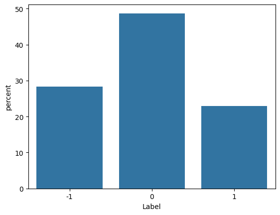

```python
sns.countplot(data=stock, x="Label", stat="percent");
```

Observation:

This is an imbalanced data

The class 0 (neutral) has the highest proportion — likely over 45% of the dataset.

This means the model may become biased toward predicting neutral sentiment unless we balance the classes.

#### Density Plot of Price (Open,High,Low,Close)

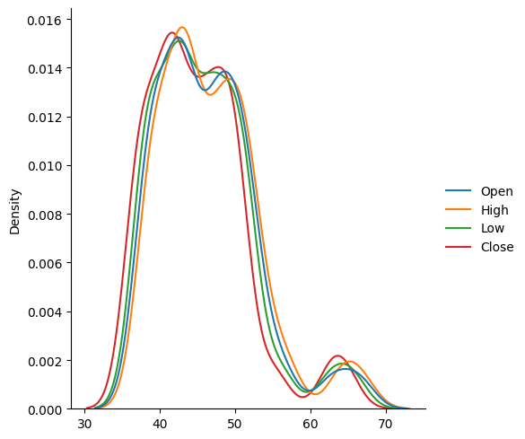

```python
sns.displot(data=stock[['Open', 'High', 'Low', 'Close']], kind="kde", palette="tab10");
```

Observations:

#### Observations on Volume

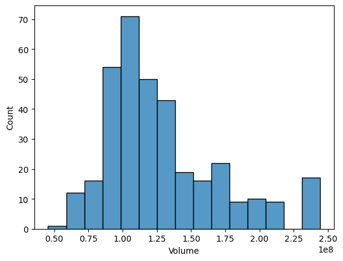

```python
sns.histplot(stock, x='Volume'); # Complete the code to plot a histogram of Volume
```

Observations:

This a slightly right skewed data. Since there are bars on the right side , those are high volume trading days. There is a high concentration around 80M 125M range.

#### Observations on News length

```python
#Calculating the total number of words present in the news content.
stock['news_len'] = stock['News'].apply(lambda x: len(x.split(' ')))


stock['news_len'].describe()   #Complete the code to print the statistical summary for the news content length
```

|  | news_len |
| --- | --- |
| count | 349.000000 |
| mean | 49.312321 |
| std | 5.727770 |
| min | 19.000000 |
| 25% | 46.000000 |
| 50% | 50.000000 |
| 75% | 53.000000 |
| max | 61.000000 |

**dtype:** float64

Observations:

Most news entries are around 49–50 words. The standard deviation is 5.73, indicating low dispersion. The min (19) and max (61) are within a close range.

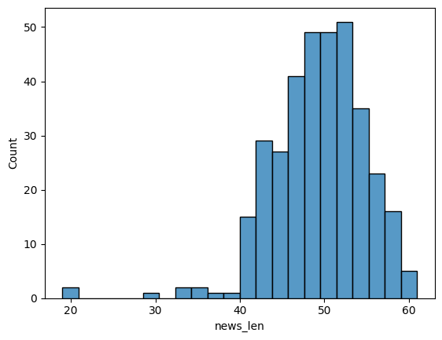

```python
sns.histplot(data=stock, x="news_len");
```

Observations: